# sparkify-udacity

#### Sparkify Project

In this project we are going to predict users churn for a music-based streaming service platform through its users log data. The aim is to detect the number of users who potentially will cancel theirs accounts in Sparkify.

To conduct this project, we are going to use "Databricks Community" platform to perform the processing. Databricks allows you to use their platform to access their Cloud-based Spark environment.

The link to the original notebook, which can be run there too is the following:

- https://databricks-prod-cloudfront.cloud.databricks.com/public/4027ec902e239c93eaaa8714f173bcfc/6246151171355951/1214521649023240/5956692570509628/latest.html

The way in which we have driven the model building is the following:

1. Data Gathering
2. Feature Engineering
3. Data Visualization
4. Machine Learning Modelling
5. Conclusions

### Data Gathering

```python
sparkify_data = spark.sql("select * from medium_sparkify_event_data_9e3be_json")
display(sparkify_data.select("*"))
```

| artist | auth | firstName | gender | itemInSession | lastName | length | level | location | method | page | registration | sessionId | song | status | ts | userAgent | userId |
| --- | --- | --- | --- | --- | --- | --- | --- | --- | --- | --- | --- | --- | --- | --- | --- | --- | --- |
| Martin Orford | Logged In | Joseph | M | 20 | Morales | 597.55057 | free | Corpus Christi, TX | PUT | NextSong | 1532063507000 | 292 | Grand Designs | 200 | 1538352011000 | "Mozilla/5.0 (Macintosh; Intel Mac OS X 10_9_4) AppleWebKit/537.36 (KHTML, like Gecko) Chrome/36.0.1985.125 Safari/537.36" | 293 |
| John Brown's Body | Logged In | Sawyer | M | 74 | Larson | 380.21179 | free | Houston-The Woodlands-Sugar Land, TX | PUT | NextSong | 1538069638000 | 97 | Bulls | 200 | 1538352025000 | "Mozilla/5.0 (Macintosh; Intel Mac OS X 10_9_4) AppleWebKit/537.36 (KHTML, like Gecko) Chrome/36.0.1985.143 Safari/537.36" | 98 |
| Afroman | Logged In | Maverick | M | 184 | Santiago | 202.37016 | paid | Orlando-Kissimmee-Sanford, FL | PUT | NextSong | 1535953455000 | 178 | Because I Got High | 200 | 1538352118000 | "Mozilla/5.0 (Macintosh; Intel Mac OS X 10_9_4) AppleWebKit/537.36 (KHTML, like Gecko) Chrome/36.0.1985.143 Safari/537.36" | 179 |
| null | Logged In | Maverick | M | 185 | Santiago | null | paid | Orlando-Kissimmee-Sanford, FL | PUT | Logout | 1535953455000 | 178 | null | 307 | 1538352119000 | "Mozilla/5.0 (Macintosh; Intel Mac OS X 10_9_4) AppleWebKit/537.36 (KHTML, like Gecko) Chrome/36.0.1985.143 Safari/537.36" | 179 |
| Lily Allen | Logged In | Gianna | F | 22 | Campos | 194.53342 | paid | Mobile, AL | PUT | NextSong | 1535931018000 | 245 | Smile (Radio Edit) | 200 | 1538352124000 | Mozilla/5.0 (Windows NT 6.1; WOW64; rv:31.0) Gecko/20100101 Firefox/31.0 | 246 |
| Carter USM | Logged In | Sofia | F | 266 | Gordon | 138.29179 | paid | Rochester, MN | PUT | NextSong | 1533175710000 | 162 | Airplane Food | 200 | 1538352125000 | "Mozilla/5.0 (Macintosh; Intel Mac OS X 10_9_4) AppleWebKit/537.36 (KHTML, like Gecko) Chrome/37.0.2062.94 Safari/537.36" | 163 |
| null | Logged Out | null | null | 186 | null | null | paid | null | GET | Home | null | 178 | null | 200 | 1538352148000 | null |  |
| null | Logged Out | null | null | 187 | null | null | paid | null | GET | Home | null | 178 | null | 200 | 1538352151000 | null |  |
| null | Logged Out | null | null | 188 | null | null | paid | null | GET | Home | null | 178 | null | 200 | 1538352168000 | null |  |
| null | Logged Out | null | null | 189 | null | null | paid | null | PUT | Login | null | 178 | null | 307 | 1538352169000 | null |  |
| null | Logged In | Maverick | M | 190 | Santiago | null | paid | Orlando-Kissimmee-Sanford, FL | GET | Home | 1535953455000 | 178 | null | 200 | 1538352176000 | "Mozilla/5.0 (Macintosh; Intel Mac OS X 10_9_4) AppleWebKit/537.36 (KHTML, like Gecko) Chrome/36.0.1985.143 Safari/537.36" | 179 |
| Aerosmith | Logged In | Lacey | F | 107 | Castaneda | 220.39465 | free | El Campo, TX | PUT | NextSong | 1537536032000 | 442 | Walk This Way | 200 | 1538352215000 | "Mozilla/5.0 (Macintosh; Intel Mac OS X 10_10_0) AppleWebKit/537.36 (KHTML, like Gecko) Chrome/37.0.2062.94 Safari/537.36" | 175 |
| null | Logged In | Colin | M | 0 | Larson | null | free | Dallas-Fort Worth-Arlington, TX | GET | Home | 1537982255000 | 497 | null | 200 | 1538352241000 | Mozilla/5.0 (Windows NT 6.1; WOW64; rv:30.0) Gecko/20100101 Firefox/30.0 | 100 |
| Amy Winehouse | Logged In | Colin | M | 1 | Larson | 201.50812 | free | Dallas-Fort Worth-Arlington, TX | PUT | NextSong | 1537982255000 | 497 | Teach Me Tonight | 200 | 1538352259000 | Mozilla/5.0 (Windows NT 6.1; WOW64; rv:30.0) Gecko/20100101 Firefox/30.0 | 100 |
| Drake / Kanye West / Lil Wayne / Eminem | Logged In | Sofia | F | 267 | Gordon | 357.66812 | paid | Rochester, MN | PUT | NextSong | 1533175710000 | 162 | Forever | 200 | 1538352263000 | "Mozilla/5.0 (Macintosh; Intel Mac OS X 10_9_4) AppleWebKit/537.36 (KHTML, like Gecko) Chrome/37.0.2062.94 Safari/537.36" | 163 |
| Bob Dylan | Logged In | Gianna | F | 23 | Campos | 256.96608 | paid | Mobile, AL | PUT | NextSong | 1535931018000 | 245 | Simple Twist Of Fate | 200 | 1538352318000 | Mozilla/5.0 (Windows NT 6.1; WOW64; rv:31.0) Gecko/20100101 Firefox/31.0 | 246 |
| The Bar-Kays | Logged In | Maverick | M | 191 | Santiago | 164.23138 | paid | Orlando-Kissimmee-Sanford, FL | PUT | NextSong | 1535953455000 | 178 | Montego Bay | 200 | 1538352320000 | "Mozilla/5.0 (Macintosh; Intel Mac OS X 10_9_4) AppleWebKit/537.36 (KHTML, like Gecko) Chrome/36.0.1985.143 Safari/537.36" | 179 |
| Black Kids | Logged In | Payton | F | 83 | Campbell | 251.48036 | free | Los Angeles-Long Beach-Anaheim, CA | PUT | NextSong | 1529027541000 | 38 | Look At Me (When I Rock Wichoo) | 200 | 1538352323000 | "Mozilla/5.0 (Windows NT 6.1; WOW64) AppleWebKit/537.36 (KHTML, like Gecko) Chrome/37.0.2062.103 Safari/537.36" | 39 |
| null | Logged In | Sofia | F | 268 | Gordon | null | paid | Rochester, MN | GET | Downgrade | 1533175710000 | 162 | null | 200 | 1538352336000 | "Mozilla/5.0 (Macintosh; Intel Mac OS X 10_9_4) AppleWebKit/537.36 (KHTML, like Gecko) Chrome/37.0.2062.94 Safari/537.36" | 163 |
| null | Logged In | Maverick | M | 192 | Santiago | null | paid | Orlando-Kissimmee-Sanford, FL | PUT | Add to Playlist | 1535953455000 | 178 | null | 200 | 1538352376000 | "Mozilla/5.0 (Macintosh; Intel Mac OS X 10_9_4) AppleWebKit/537.36 (KHTML, like Gecko) Chrome/36.0.1985.143 Safari/537.36" | 179 |
| Chris Isaak | Logged In | Sawyer | M | 75 | Larson | 157.67465 | free | Houston-The Woodlands-Sugar Land, TX | PUT | NextSong | 1538069638000 | 97 | Solitary Man (LP Version) | 200 | 1538352405000 | "Mozilla/5.0 (Macintosh; Intel Mac OS X 10_9_4) AppleWebKit/537.36 (KHTML, like Gecko) Chrome/36.0.1985.143 Safari/537.36" | 98 |
| Crazy Frog | Logged In | Lacey | F | 108 | Castaneda | 169.50812 | free | El Campo, TX | PUT | NextSong | 1537536032000 | 442 | Popcorn (Radio Mix) | 200 | 1538352435000 | "Mozilla/5.0 (Macintosh; Intel Mac OS X 10_10_0) AppleWebKit/537.36 (KHTML, like Gecko) Chrome/37.0.2062.94 Safari/537.36" | 175 |
| null | Logged In | Sawyer | M | 76 | Larson | null | free | Houston-The Woodlands-Sugar Land, TX | GET | Roll Advert | 1538069638000 | 97 | null | 200 | 1538352435000 | "Mozilla/5.0 (Macintosh; Intel Mac OS X 10_9_4) AppleWebKit/537.36 (KHTML, like Gecko) Chrome/36.0.1985.143 Safari/537.36" | 98 |
| The Strokes | Logged In | Colin | M | 2 | Larson | 187.34975 | free | Dallas-Fort Worth-Arlington, TX | PUT | NextSong | 1537982255000 | 497 | You Only Live Once | 200 | 1538352460000 | Mozilla/5.0 (Windows NT 6.1; WOW64; rv:30.0) Gecko/20100101 Firefox/30.0 | 100 |
| null | Logged In | Colin | M | 3 | Larson | null | free | Dallas-Fort Worth-Arlington, TX | GET | Roll Advert | 1537982255000 | 497 | null | 200 | 1538352460000 | Mozilla/5.0 (Windows NT 6.1; WOW64; rv:30.0) Gecko/20100101 Firefox/30.0 | 100 |
| Old 97's | Logged In | Maverick | M | 193 | Santiago | 219.89832 | paid | Orlando-Kissimmee-Sanford, FL | PUT | NextSong | 1535953455000 | 178 | Buick City Complex | 200 | 1538352484000 | "Mozilla/5.0 (Macintosh; Intel Mac OS X 10_9_4) AppleWebKit/537.36 (KHTML, like Gecko) Chrome/36.0.1985.143 Safari/537.36" | 179 |
| Camila | Logged In | Sawyer | M | 77 | Larson | 194.84689 | free | Houston-The Woodlands-Sugar Land, TX | PUT | NextSong | 1538069638000 | 97 | Todo Cambio | 200 | 1538352562000 | "Mozilla/5.0 (Macintosh; Intel Mac OS X 10_9_4) AppleWebKit/537.36 (KHTML, like Gecko) Chrome/36.0.1985.143 Safari/537.36" | 98 |
| The Script | Logged In | Gianna | F | 24 | Campos | 260.67546 | paid | Mobile, AL | PUT | NextSong | 1535931018000 | 245 | Breakeven | 200 | 1538352574000 | Mozilla/5.0 (Windows NT 6.1; WOW64; rv:31.0) Gecko/20100101 Firefox/31.0 | 246 |
| Beastie Boys | Logged In | Payton | F | 84 | Campbell | 133.22404 | free | Los Angeles-Long Beach-Anaheim, CA | PUT | NextSong | 1529027541000 | 38 | Pow (2009 Digital Remaster) | 200 | 1538352574000 | "Mozilla/5.0 (Windows NT 6.1; WOW64) AppleWebKit/537.36 (KHTML, like Gecko) Chrome/37.0.2062.103 Safari/537.36" | 39 |
| Tungtvann | Logged In | Lacey | F | 109 | Castaneda | 239.22893 | free | El Campo, TX | PUT | NextSong | 1537536032000 | 442 | T D Her | 200 | 1538352604000 | "Mozilla/5.0 (Macintosh; Intel Mac OS X 10_10_0) AppleWebKit/537.36 (KHTML, like Gecko) Chrome/37.0.2062.94 Safari/537.36" | 175 |

[output cut: 970 more lines]

##### Define several data transformations

```python
from datetime import datetime
from pyspark.sql.functions import udf, col
from pyspark.sql.functions import max as sparkmax, min as sparkmin, to_timestamp

# Apply mapping for churn criticality
churn_classes_criticality = {"Cancellation Confirmation": 1}

# Read Data
df = spark.sql("select * from medium_sparkify_event_data_9e3be_json")

# UDFs
criticalityMapper = udf(lambda page: churn_classes_criticality[page] if page in churn_classes_criticality.keys() else 0)
tsToDate = udf(lambda ts: datetime.fromtimestamp(ts/1000).strftime("%Y-%m-%d %H:%M:%S"))
levelMapper = udf(lambda lev: 1 if lev == "paid" else 0)
genderMapper = udf(lambda gen: 1 if gen == "M" else 0)

# Data Conversions
df = df.where(df["userId"] != "").where(df["userId"].isNotNull())
df = df.withColumn("churn", criticalityMapper("page"))
df = df.withColumn("level", levelMapper("level"))
df = df.withColumn("gender", genderMapper("gender"))
df = df.withColumn("ts", tsToDate("ts"))
# df = df.withColumn("ts", to_timestamp("ts"))
df = df.withColumn("userId", df["userId"].cast("integer"))
df = df.withColumn("sessionId", df["sessionId"].cast("integer"))
df = df.withColumn("length", df["length"].cast("float"))
```

### Feature Engineering

```python
from pyspark.sql import functions as pyfun
from pyspark.sql.window import Window
from pyspark.sql import functions as F

def getSongsPlayedByUser(dataFrameIn):
    dataFrameOut = dataFrameIn.where(dataFrameIn["page"] == "NextSong").groupby("userId").agg({"page" : "count"}).withColumnRenamed("count(page)", "total_songs_played")
    return dataFrameOut

def getHoursByUsers(dataFrameIn):
    dataFrameOut = dataFrameIn.groupby("userId").agg({"length" : "sum"}).withColumnRenamed("sum(length)", "total_hours").withColumn("total_hours", col("total_hours").cast("integer"))
    return dataFrameOut

def getTotalSessionsByUser(dataFrameIn):
    dataFrameOut = dataFrameIn.groupby("userId").agg(pyfun.countDistinct("sessionId")).withColumnRenamed("count(DISTINCT sessionId)", "total_sessions")
    return dataFrameOut

def getMeanHoursPerSession(dataFrameIn):
    dataFrameOut = dataFrameIn.select("userId", "length", "sessionId").groupby(["userId", "sessionId"]).agg({"length": "sum"}).groupby("userId").agg({"sum(length)": "average"}).withColumnRenamed("avg(sum(length))", "avg_hours_per_session").withColumn("avg_hours_per_session", col("avg_hours_per_session").cast("integer"))
    return dataFrameOut

def getLevelChanges(dataFrameIn):
    dataFrameOut = dataFrameIn.groupby("userId", "level").agg(pyfun.count("level").alias("nlevel")).withColumn("nzeros", pyfun.when(pyfun.col("level") == 0, pyfun.col("nlevel")).otherwise(0)).withColumn("nones", pyfun.when(pyfun.col("level") == 1, pyfun.col("nlevel")).otherwise(0)).select("userId", "nzeros", "nones").groupBy("userId").agg({"nzeros": "sum", "nones" : "sum"}).withColumnRenamed("sum(nzeros)", "n_free_items").withColumnRenamed("sum(nones)", "n_paid_items")
    return dataFrameOut

def getCountOfStages(dataFrameIn):
    dataFrameOut_0 = dataFrameIn.where(pyfun.col("page") == "Thumbs Down").groupby("userId").agg({"page" : "count"}).withColumnRenamed("count(page)", "n_thumbs_down")
    dataFrameOut_1 = dataFrameIn.where(pyfun.col("page") == "Thumbs Up").groupby("userId").agg({"page" : "count"}).withColumnRenamed("count(page)", "n_thumbs_up")
    dataFrameOut_2 = dataFrameIn.where(pyfun.col("page") == "Upgrade").groupby("userId").agg({"page" : "count"}).withColumnRenamed("count(page)", "n_upgrades")
    dataFrameOut_3 = dataFrameIn.where(pyfun.col("page") == "Help").groupby("userId").agg({"page" : "count"}).withColumnRenamed("count(page)", "n_helps")
    dataFrameOut = dataFrameOut_0.join(dataFrameOut_1, "userId").join(dataFrameOut_2, "userId").join(dataFrameOut_3, "userId")
    return dataFrameOut

def getChurnsByUser(dataFrameIn):
    dataFrameOut = dataFrameIn.groupBy("userId").agg({"churn": "sum"}).withColumnRenamed("sum(churn)", "total_churns")
    return dataFrameOut

def getTimeSpansFeatures(dataFrameIn):

    # Get time from first use to last use
    dataFrameOut1 = dataFrameIn.groupby("userId").agg({"ts": "min"}).withColumnRenamed("min(ts)", "first_use_ts")
    dataFrameOut2 = dataFrameIn.groupby("userId").agg({"ts": "max"}).withColumnRenamed("max(ts)", "last_use_ts")
    dataFrameOut = dataFrameOut2.join(dataFrameOut1, "userId")
    dataFrameOut = dataFrameOut.withColumn("first_use_ts", pyfun.unix_timestamp(dataFrameOut.first_use_ts))
    dataFrameOut = dataFrameOut.withColumn("last_use_ts", pyfun.unix_timestamp(dataFrameOut.last_use_ts))
    dataFrameOut = dataFrameOut.withColumn("time_from_first_use_to_last", pyfun.col("last_use_ts") - pyfun.col("first_use_ts"))

    # Get average time between sessions
    dataFrameOut_ = dataFrameIn.groupby("sessionId", "userId").agg(pyfun.min("ts"), pyfun.max("ts")).sort("userid", "sessionId")
    dataFrameOut_ = dataFrameOut_.withColumn("session_duration", F.unix_timestamp(F.col("max(ts)")) - F.unix_timestamp(F.col("min(ts)")))
    window = Window.partitionBy().orderBy("userId", "sessionId")
    dataFrameOut_ = dataFrameOut_.withColumn("prev_min_ts", F.lag(F.col("min(ts)")).over(window))
    dataFrameOut_ = dataFrameOut_.withColumn("prev_user_id", F.lag(F.col("userId")).over(window))
    dataFrameOut_ = dataFrameOut_.withColumn("time_between_session",
                     F.when(F.col("prev_user_id") != "null", 0).when(F.col("prev_user_id") == F.col("userId"),
                            F.unix_timestamp(F.col("max(ts)")) - F.unix_timestamp(F.col("prev_min_ts"))).otherwise(0))
    dataFrameOut_ = dataFrameOut_.groupby("userId").agg({"time_between_session": "avg"}).withColumnRenamed("avg(time_between_session)", "avg_time_between_session").withColumn("avg_time_between_session", F.col("avg_time_between_session").cast("integer"))
    dataFrameOut_ = dataFrameOut_.withColumn("avg_time_between_session", F.col("avg_time_between_session")/86400)
    dataFrameOut_ = dataFrameOut_.withColumn("avg_time_between_session", F.round(F.col("avg_time_between_session"), 2))
    dataFrameOut_ = dataFrameOut_.withColumnRenamed("avg_time_between_session", "avg_days_between_session")
    dataFrameOutFinal = dataFrameOut.join(dataFrameOut_, "userId")
    return dataFrameOutFinal

df_hoursByUser = getHoursByUsers(df)
df_songsByUser = getSongsPlayedByUser(df)
df_sessionsByUser = getTotalSessionsByUser(df)
df_meanHoursPerSession = getMeanHoursPerSession(df)
df_levelChanges = getLevelChanges(df)
df_stagesCount = getCountOfStages(df)
df_withChurns = getChurnsByUser(df)
df_withTimeSpans = getTimeSpansFeatures(df)

dfFinal = df_hoursByUser.join(df_songsByUser, "userId").join(df_sessionsByUser, "userId").join(df_meanHoursPerSession, "userId").join(df_levelChanges, "userId").join(df_stagesCount, "userId").join(df_withChurns, "userId").join(df_withTimeSpans, "userId")
dfFinal = dfFinal.withColumn("total_hours", dfFinal["total_hours"].cast("integer"))
dfFinal = dfFinal.withColumn("total_songs_played", dfFinal["total_songs_played"].cast("integer"))
dfFinal = dfFinal.withColumn("avg_hours_per_session", dfFinal["avg_hours_per_session"].cast("integer"))
dfFinal = dfFinal.withColumn("n_free_items", dfFinal["n_free_items"].cast("integer"))
dfFinal = dfFinal.withColumn("n_paid_items", dfFinal["n_paid_items"].cast("integer"))
dfFinal = dfFinal.withColumn("n_thumbs_down", dfFinal["n_thumbs_down"].cast("integer"))
dfFinal = dfFinal.withColumn("n_upgrades", dfFinal["n_upgrades"].cast("integer"))
dfFinal = dfFinal.withColumn("n_helps", dfFinal["n_helps"].cast("integer"))
dfFinal = dfFinal.withColumn("total_churns", dfFinal["total_churns"].cast("integer"))

display(dfFinal)
```

| userId | total_hours | total_songs_played | total_sessions | avg_hours_per_session | n_free_items | n_paid_items | n_thumbs_down | n_thumbs_up | n_upgrades | n_helps | total_churns | last_use_ts | first_use_ts | time_from_first_use_to_last | avg_days_between_session |
| --- | --- | --- | --- | --- | --- | --- | --- | --- | --- | --- | --- | --- | --- | --- | --- |
| 300040 | 130921 | 524 | 8 | 21820 | 316 | 348 | 10 | 52 | 3 | 4 | 0 | 1543586189 | 1538755115 | 4831074 | 7.04 |
| 85 | 550835 | 2223 | 32 | 18361 | 492 | 2204 | 33 | 116 | 4 | 13 | 1 | 1543570037 | 1538388789 | 5181248 | 2.07 |
| 251 | 512983 | 2072 | 23 | 22303 | 565 | 1952 | 16 | 117 | 3 | 16 | 0 | 1543500273 | 1538386371 | 5113902 | 2.81 |
| 65 | 442823 | 1782 | 27 | 17031 | 490 | 1669 | 15 | 89 | 7 | 8 | 0 | 1543525111 | 1538416736 | 5108375 | 2.37 |
| 53 | 449392 | 1833 | 16 | 29959 | 119 | 2098 | 17 | 110 | 1 | 13 | 0 | 1543520407 | 1538418773 | 5101634 | 4.01 |
| 100003 | 162292 | 661 | 9 | 20286 | 313 | 514 | 10 | 16 | 2 | 3 | 1 | 1541661592 | 1539100420 | 2561172 | 3.47 |
| 200021 | 313583 | 1257 | 16 | 19598 | 507 | 1064 | 45 | 51 | 3 | 4 | 1 | 1541468030 | 1538585959 | 2882071 | 2.28 |
| 78 | 310521 | 1266 | 16 | 19407 | 320 | 1244 | 16 | 66 | 4 | 4 | 0 | 1543448119 | 1538375415 | 5072704 | 3.87 |
| 100007 | 210102 | 853 | 12 | 17508 | 179 | 873 | 6 | 40 | 2 | 1 | 0 | 1543483022 | 1538524316 | 4958706 | 4.93 |
| 100042 | 68557 | 271 | 5 | 13711 | 268 | 109 | 11 | 12 | 1 | 1 | 1 | 1540435643 | 1538413902 | 2021741 | 4.74 |
| 100035 | 180263 | 727 | 8 | 22532 | 202 | 694 | 8 | 29 | 2 | 4 | 0 | 1543596681 | 1539923779 | 3672902 | 5.44 |
| 300011 | 980001 | 3921 | 60 | 16610 | 162 | 4654 | 40 | 344 | 4 | 25 | 0 | 1543584205 | 1538430493 | 5153712 | 1.17 |
| 34 | 308366 | 1239 | 8 | 38545 | 175 | 1299 | 11 | 59 | 3 | 7 | 1 | 1543337414 | 1539213305 | 4124109 | 6.25 |
| 101 | 1440433 | 5745 | 53 | 27177 | 102 | 6740 | 55 | 305 | 3 | 30 | 0 | 1543540389 | 1538358722 | 5181667 | 1.46 |
| 126 | 875889 | 3548 | 28 | 31281 | 135 | 4055 | 37 | 167 | 3 | 21 | 1 | 1542933610 | 1538387004 | 4546606 | 2.22 |
| 300010 | 255309 | 1022 | 10 | 25530 | 191 | 1079 | 9 | 88 | 7 | 8 | 0 | 1543622316 | 1538775518 | 4846798 | 5.82 |
| 28 | 174288 | 692 | 13 | 13406 | 492 | 386 | 7 | 26 | 1 | 2 | 1 | 1539968001 | 1538363502 | 1604499 | 1.54 |
| 183 | 173502 | 697 | 18 | 10206 | 519 | 370 | 11 | 38 | 4 | 5 | 0 | 1543476287 | 1538685665 | 4790622 | 3.18 |
| 210 | 61411 | 255 | 6 | 10235 | 21 | 300 | 5 | 13 | 1 | 2 | 0 | 1541467566 | 1538905888 | 2561678 | 5.05 |
| 76 | 271094 | 1105 | 12 | 22591 | 93 | 1205 | 14 | 45 | 1 | 1 | 0 | 1543505682 | 1538498831 | 5006851 | 5.06 |
| 27 | 363024 | 1464 | 19 | 19106 | 165 | 1595 | 8 | 79 | 3 | 7 | 0 | 1543622376 | 1538400348 | 5222028 | 3.37 |
| 159 | 80522 | 317 | 12 | 6710 | 418 | 0 | 4 | 15 | 1 | 4 | 0 | 1543577820 | 1538543900 | 5033920 | 4.93 |
| 200014 | 25869 | 101 | 4 | 6467 | 91 | 53 | 3 | 3 | 3 | 1 | 0 | 1541071942 | 1540389866 | 682076 | 2.0 |
| 200028 | 233908 | 943 | 13 | 17992 | 506 | 682 | 28 | 39 | 4 | 8 | 1 | 1542162058 | 1538470355 | 3691703 | 3.44 |
| 253 | 156689 | 631 | 9 | 17409 | 311 | 481 | 5 | 35 | 3 | 1 | 0 | 1543386679 | 1540565163 | 2821516 | 3.75 |
| 103 | 103043 | 423 | 13 | 8586 | 341 | 200 | 2 | 21 | 3 | 4 | 0 | 1543218836 | 1538648520 | 4570316 | 4.16 |
| 200019 | 301999 | 1202 | 19 | 15894 | 584 | 920 | 41 | 67 | 2 | 12 | 0 | 1543233709 | 1538392417 | 4841292 | 3.13 |
| 12 | 872550 | 3548 | 24 | 37936 | 195 | 4037 | 39 | 172 | 3 | 16 | 0 | 1543622337 | 1538533625 | 5088712 | 2.91 |
| 200046 | 115190 | 454 | 13 | 8860 | 189 | 382 | 10 | 27 | 2 | 3 | 0 | 1542928255 | 1538814932 | 4113323 | 3.75 |
| 223 | 278219 | 1096 | 23 | 12096 | 475 | 914 | 8 | 76 | 2 | 5 | 1 | 1541958736 | 1538355394 | 3603342 | 1.94 |

[output cut: 230 more lines]

### Data Visualization

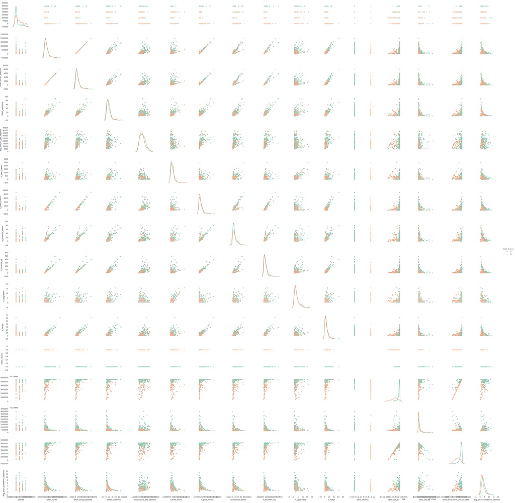

```python
import seaborn as sns
import matplotlib.pyplot as plt
g = sns.pairplot(dfFinal.toPandas(), hue="total_churns", palette="Set2", diag_kind="kde")
display(g.fig)
```

In this pairplot we can see the scatter plots for all the different variables and the distribution plots for the univariate plots. In all of them we can distinguish between the "churn" users and the "not churn" users. This graph is clearer to see in the Databricks notebook.

Some interestings conclusions from these plots:

1. As a general rule, we can see that almost all the "churn" users rates can be located at the bottom-left side of the plots. This can be a sign of the "low" activity presented by them.
2. There are more "not churn" users with low "Thumbs Down" actions.
3. There are variables that are highly correlated, such as:
   - total_songs_played -- paid_items
   - n_helps -- total_songs_played

### Machine Learning Modelling - Scaling and Normalizing Features

```python
from pyspark.ml.feature import Normalizer, StandardScaler
from pyspark.ml.feature import VectorAssembler
assembler = VectorAssembler(
  inputCols=["total_hours", "total_songs_played",
             "avg_hours_per_session", "n_free_items",
             "n_paid_items", "n_thumbs_down", "n_thumbs_up",
             "n_upgrades", "n_helps", "avg_days_between_session"],
  outputCol="features")

dfAssembled = assembler.transform(dfFinal)
```

```python
scaler = StandardScaler(inputCol="features", outputCol = "scaled_features")
model = scaler.fit(dfAssembled)
dfScaled = model.transform(dfAssembled) #.collect()
normalizer = Normalizer(inputCol="features", outputCol="normFeatures", p=1.0)
dfScaled = normalizer.transform(dfScaled)
```

```python
display(dfScaled)
```

[output not shown]

[output cut: 230 more lines]